# Hands-on in Julia

```julia
using CSV, DataFrames, DataFramesMeta, CategoricalArrays
using AlgebraOfGraphics, CairoMakie
using AlgebraOfGraphics: density
```

```julia
using Random, StatsBase, Distributions
```

```julia
# Read the data file and store the data in data frame
demog = CSV.read("../data/demographics_1.csv", DataFrame);
```

For our analysis, we will use a dataset called `demographics_1.csv`, which includes data collected from 100 patients. This dataset contains several columns, each representing different types of information:

- ID: Each patient has a unique identifier, or Patient ID.
- AGE: This column shows the age of each patient.
- WEIGHT: This records the weight of each patient.
- SRC: Serum Creatinine (SRC) measures the level of creatinine in a patient's blood. Creatinine is a waste product, and its levels in the blood can tell us about kidney function.
- ISMALE: This is a binary indicator, noting whether the patient is male (1) or not (0).
- eGFR: The estimated Glomerular Filtration Rate (eGFR) is a calculation based on the serum creatinine level along with other factors like age and gender. It helps assess how well the kidneys are filtering blood.

In addition to the columns previously described in our dataset, we've also included a new column titled `GENDER`. This column is derived from the `ISMALE` column, which indicated whether each patient was male or not. In the GENDER column, we categorize each patient as either `Male` or `Female`. This transformation makes the data more straightforward to understand and analyze, especially when comparing health outcomes or treatments between different genders. We specify `Male` for those entries where `ISMALE` is 1, and `Female` for entries where `ISMALE` is 0.

```julia
@transform! demog :GENDER = recode(:ISMALE, 0 => "Female", 1 => "Male")
first(demog, 5);
```

### Central Limit Theorem

```
The skewness = 0.0013480592050649646
The kurtosis = -0.003994326305921003
```

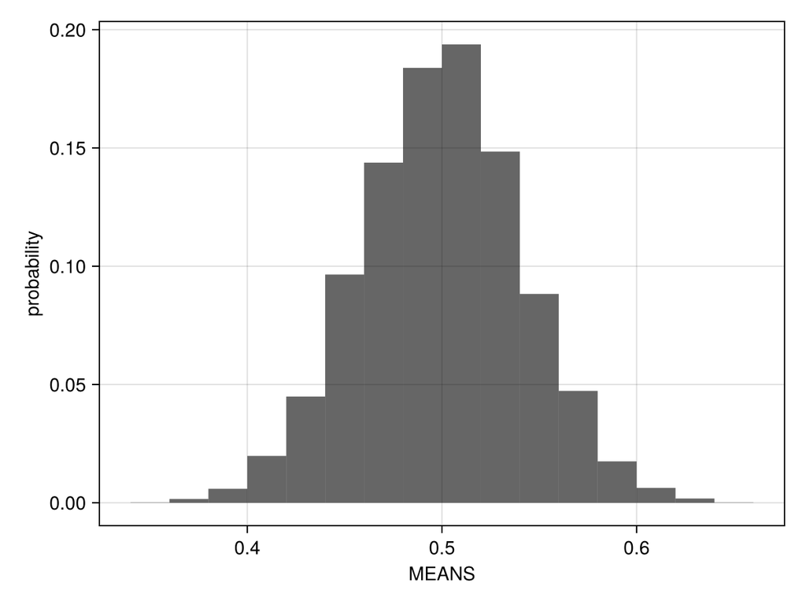

```julia
# Function to generate means of random samples
function sample_means(dist, sample_size, num_samples)
    means = [0.5]
    for i in 1:num_samples
        sample = rand(dist, sample_size)
        push!(means, mean(sample))
    end
    return means
end

# Parameters
sample_size = 50        # Number of observations in each sample
num_samples = 10000     # Number of samples

# Generate sample means from a uniform distribution
uniform_dist = Uniform(0, 1)
means_clt = DataFrame("MEANS"=> sample_means(uniform_dist, sample_size, num_samples))

println("The skewness = ",skewness(means_clt.MEANS))
println("The kurtosis = ",kurtosis(means_clt.MEANS))

data(means_clt) * mapping(:MEANS) * histogram(normalization=:probability, bins = 20) |> draw
```

### T Distribution

```
Mean: 0.02109745444318057
Median: 0.01010578185109464
Variance: 1.0334827920993623
The skewness = 0.01750218134508739
The kurtosis = 0.06609573559493231
```

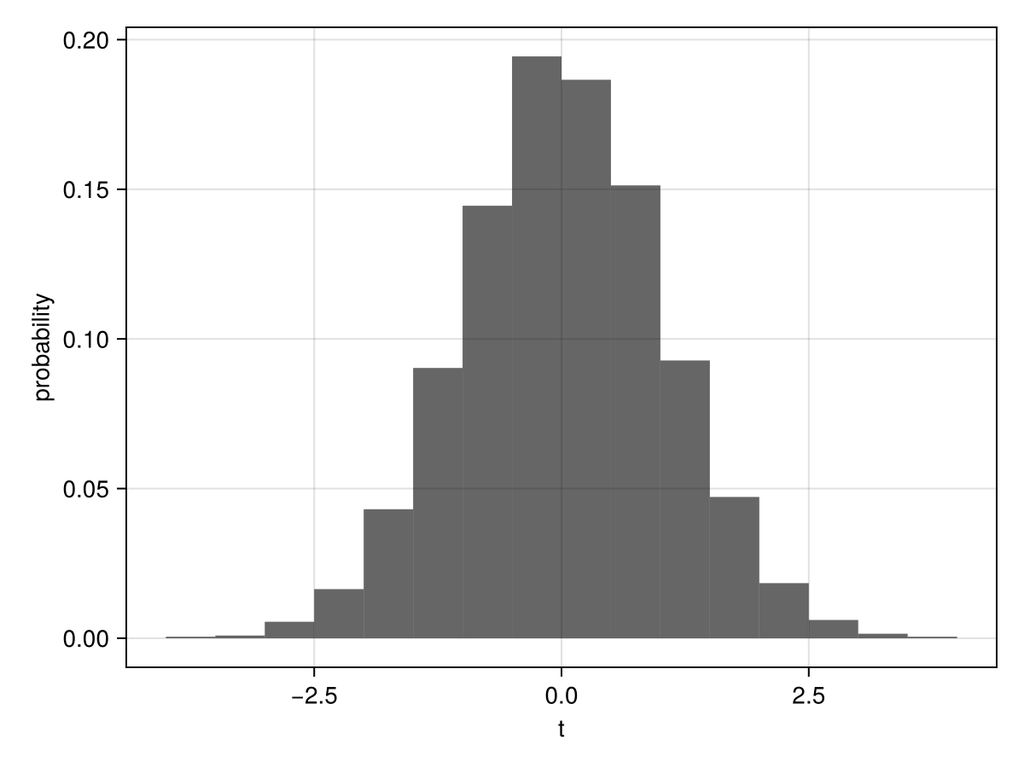

```julia
df = 100
dist = TDist(df)
samples = rand(dist, 10000)
df = DataFrame("t"=> samples)

println("Mean: ", mean(df.t))
println("Median: ", median(df.t))
println("Variance: ", var(df.t))

println("The skewness = ",skewness(df.t))
println("The kurtosis = ",kurtosis(df.t))

data(df) * mapping(:t) * histogram(normalization=:probability, bins = 20) |> draw
```

### Bootstrap method

```julia
using Statistics, Random

# Function to perform bootstrap sampling
function bootstrap_sample(data, n)
    return [data[rand(1:end)] for _ in 1:n]
end

# Function to perform bootstrapping to estimate standard error and confidence interval
function bootstrap_estimation(data, num_samples, alpha=0.05)
    n = length(data)
    means = Float64[]

    sample_mean = mean(data)

    # Generate bootstrap samples and calculate their means
    for i in 1:num_samples
        sample = bootstrap_sample(data, n)
        push!(means, mean(sample))
    end

    # Estimate the standard error of the mean
    se = std(means)

    # generate delta, bias
    deltas = means .- mean(means)
    #println(deltas)

    # Calculate the confidence interval
    lower_bound = quantile(deltas, alpha/2)
    upper_bound = quantile(deltas, 1 - alpha/2)

    return (mean_estimate = mean(means), standard_error = se, ci = (sample_mean - upper_bound, sample_mean - lower_bound))
end

# Example data
values = [4.5, 5.1, 6.7, 7.8, 5.9, 4.2, 6.5, 7.1, 6.3, 5.4]

# Perform bootstrap estimation
results = bootstrap_estimation(values, 10000)

# Display the results
println("Mean Estimate: ", results.mean_estimate)
println("Standard Error: ", results.standard_error)
println("95% Confidence Interval: ", results.ci)
```

```
Mean Estimate: 5.956501999999999
Standard Error: 0.3482624479746084
95% Confidence Interval: (5.276501999999999, 6.636501999999998)
```

### MLE

```julia
using  Optim

# Generate synthetic data from a normal distribution
Random.seed!(42)  # For reproducibility
μ_true = 5.0  # True mean
σ_true = 2.0  # True standard deviation
n_samples = 1000  # Number of samples

values = rand(Normal(μ_true, σ_true), n_samples)

# Define the log-likelihood function for normal distribution
function neg_log_likelihood(params, data)
    μ, σ = params
    dist = Normal(μ, σ)
    loglik = sum(logpdf(dist, x) for x in data)
    return -loglik  # Negative log-likelihood for minimization
end

# Initial guesses for μ and σ
initial_params = [1.0, 1.0]

# Perform MLE using the Optim package
result = optimize(params -> neg_log_likelihood(params, values), initial_params)

# Extract estimated parameters
μ_mle, σ_mle = Optim.minimizer(result)

println("True μ: $μ_true, Estimated μ: $μ_mle")
println("True σ: $σ_true, Estimated σ: $σ_mle")
```

```
True μ: 5.0, Estimated μ: 4.879777538395782
True σ: 2.0, Estimated σ: 1.973411346280443
```

```julia
dist = fit_mle(Normal, values)
```

```
Normal{Float64}(μ=4.879772611630948, σ=1.9734132893142813)
```